# Portfolio assignment 5

20 min:

- Download lifeExpectancyAtBirth.csv from Brightspace ([original source](https://www.kaggle.com/utkarshxy/who-worldhealth-statistics-2020-complete?select=lifeExpectancyAtBirth.csv)).
- Move the file to the same folder as the Notebook that you will be working in.
- Load the dataset in your Notebook with the following code: lifeExpectancy = pd.read_csv('lifeExpectancyAtBirth.csv', sep=',')
- Look at the dataset with the .head() function.
- Filter the dataframe: We only want the life expectancy data about 2019 and 'Both sexes'
- Use this dataframe to perform a univariate analysis on the life expectancy in 2019.
- Which five countries have the highest life expectancy? Which five the lowest?

```python
import pandas as pd
```

```python
lifeExp = pd.read_csv('lifeExpectancyAtBirth.csv', sep=',')
lifeExp.head()
```

|  | Location | Period | Indicator | Dim1 | First Tooltip |
| --- | --- | --- | --- | --- | --- |
| 0 | Afghanistan | 2019 | Life expectancy at birth (years) | Both sexes | 63.21 |
| 1 | Afghanistan | 2019 | Life expectancy at birth (years) | Male | 63.29 |
| 2 | Afghanistan | 2019 | Life expectancy at birth (years) | Female | 63.16 |
| 3 | Afghanistan | 2015 | Life expectancy at birth (years) | Both sexes | 61.65 |
| 4 | Afghanistan | 2015 | Life expectancy at birth (years) | Male | 61.04 |

### Filter data on 2019 & Both Sexes

```python
selection = lifeExp[(lifeExp.Dim1 == 'Both sexes') & (lifeExp.Period == 2019)]
```

```python
print('Rows: ' + str( len(selection) ))
```

```
Rows: 183
```

## Analysis

```python
print('Lowest expectancy:', selection['First Tooltip'].min())
```

```
Lowest expectancy: 50.75
```

```python
print('Highest expectancy:', selection['First Tooltip'].max())
```

```
Highest expectancy: 84.26
```

```python
print('Average expectancy:', selection['First Tooltip'].mean())
```

```
Average expectancy: 72.54049180327873
```

### Count of countries per life-expectancy

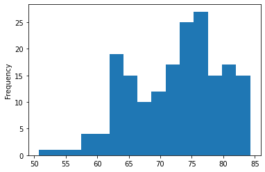

```python
selection['First Tooltip'].plot(kind='hist', bins=15)
```

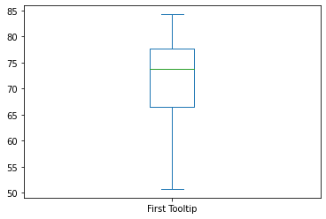

```python
selection['First Tooltip'].plot(kind='box')
```

### The best and worst countries

```python
sortSelection = selection.sort_values(ascending=False, by="First Tooltip")
sortSelection
```

|  | Location | Period | Indicator | Dim1 | First Tooltip |
| --- | --- | --- | --- | --- | --- |
| 997 | Japan | 2019 | Life expectancy at birth (years) | Both sexes | 84.26 |
| 1897 | Switzerland | 2019 | Life expectancy at birth (years) | Both sexes | 83.45 |
| 1573 | Republic of Korea | 2019 | Life expectancy at birth (years) | Both sexes | 83.30 |
| 1837 | Spain | 2019 | Life expectancy at birth (years) | Both sexes | 83.22 |
| 1753 | Singapore | 2019 | Life expectancy at birth (years) | Both sexes | 83.22 |
| ... | ... | ... | ... | ... | ... |
| 1333 | Mozambique | 2019 | Life expectancy at birth (years) | Both sexes | 58.14 |
| 661 | Eswatini | 2019 | Life expectancy at birth (years) | Both sexes | 57.73 |
| 1801 | Somalia | 2019 | Life expectancy at birth (years) | Both sexes | 56.47 |
| 373 | Central African Republic | 2019 | Life expectancy at birth (years) | Both sexes | 53.10 |
| 1117 | Lesotho | 2019 | Life expectancy at birth (years) | Both sexes | 50.75 |

183 rows × 5 columns

Japan is the best country, followed by Switzerland. The top 5 countries have an expectancy higher than 83.2 years. In the top 5 are three East-Asian countries, and two European.

The five countries with the lowest life-expectancy are all African countries. Lesotho is the worst country with 50.8 years.

### The five worst countries vs five best countries

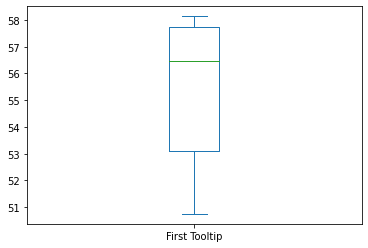

```python
sortSelection["First Tooltip"].tail(5).plot(kind="box")
```

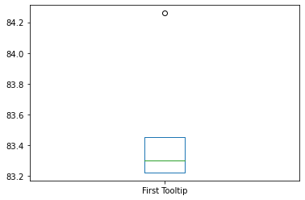

```python
sortSelection["First Tooltip"].iloc[0:5].plot(kind="box")
```

The worst countries have a high range between the minimum and maximum. The best countries have a low range, they are closer together.

We could draw the conclusion that we are pushing to the limits of the years we humans can live.

### Standard Deviation

```python
selection["First Tooltip"].std()
```

```
7.129956404370866
```